# Health vs. Income

Stat380 Final Project

Group 5 Yiyun Gong & Tsz Yau Iris Chow

```r
# always clean up R environment
rm(list = ls())
# load all packages here
library(dplyr)
library(reshape2)
library(tidyr)
library(ggplot2)
library(mosaic)
library(mdsr)
library(Lahman)
library(readxl)
library(ape)
library(mclust)
library(lubridate)
library(NHANES)
library(glmnet)
library(rpart)
library(rpart.plot)
library(randomForest)
library(nnet)
library(e1071)
library(class)
library(rsample)
library(ipred)
library(caret)
library(partykit)
library(tibble)
library(gbm)
# load dataset
health_allPop<-
  read.csv("Health_allPop.csv", header = T)
health_percapita<-
  read.csv("Health_percapita.csv", header = T)
income<-
  read.csv("income.csv", header = T)
income_num<-
  read.csv("income_num.csv", header = T)
# user-defined function
remove_comma<-
  function(table_name){
    ncol<-
      ncol(table_name)
    for (i in 2:ncol){
      table_name[,i]<-
        gsub(",","",table_name[,i])
      table_name[,i]<-
        as.numeric(table_name[,i])
    }
    return(table_name)
  }
#user-defined simulation function
hein<-
  function(a, b, c, d, e){
    health_service<-
      sample(a, 1)
    health_equipment<-
      sample(b, 1)
    medianIncome<-
      sample(c, 1)
    lowIncome<-
      sample(d, 1)
    highIncome<-
      sample(e, 1)
    health_sim<-
      health_service+health_equipment
    percent_med<-
      health_sim/medianIncome
    percent_low<-
      health_sim/lowIncome
    percent_high<-
      health_sim/highIncome

    return(data.frame(health_sim, health_service, health_equipment,
                      medianIncome, percent_med, lowIncome, percent_low,
                      highIncome,  percent_high))
  }
```

# Project Abstract for Social Good

Our analysis is related to social good by showing the cost of healthcare and healthcare spending. In further discussion, we can expand our idea of the outcome of healthcare and compare U.S. healthcare system with other countries. Furthermore, health care expense takes up a significant portion of GDP and it is affecting our consumption of other goods.

For unsupervised learning, we clustered the data according to year. We also did k-mean clustering and separate data into 8 groups.

Last but not least, we did a simulation by bootstraping income dataset. This shows us how much of insurance take up in the income of each class.

# Data Wrangling

#### Data Cleaning income_num dataset

```r
#Clean column year
income_num$Year<-
  substr(income_num$Year, 1, 4)
#Delete repeated year data
income_num<-
  income_num[-5,]
#Change the Year column to numeric number
income_num$Year<-
  as.numeric(income_num$Year)
```

```r
#remove_comman function at the user-defined function section
#Remove all the comman from the whole dataset
income_num<-
  remove_comma(income_num)
```

#### Subset datasets income_num and health_percapita

```r
income_num_sub<-
  income_num %>%
  filter(Year>1999&Year<2016)%>%
  arrange(Year)
```

```r
#remove commas from dataset health_percapita and health_allPop
health_percapita<-
  remove_comma(health_percapita)
health_allPop<-
  remove_comma(health_allPop)
```

#### Join Income table with Average insurance price per capita table

Two meaningful tables which are health_percapita table, health care expenditures on each sub section per capita and income_num_sub table, Mean Income for each fifth percent from 2000-2015 are joined together to be further analyze the how important health care expenditures take places on Income.

```r
insurance_income<-
  merge(x=income_num_sub, y=health_percapita, by = "Year", all=TRUE)
```

#### Calculate the percentage of insurance/median income

```r
insurance_income<-
  insurance_income %>%
  mutate(ins_percentage = Health/Third.fifth)
```

#### Spread Income Percentage Table by Subject and Family Status

```r
income_status<-
  income %>%
  spread(key = Subject, value = Estimate)
```

```r
income_subject<-
  income %>%
  spread(key = Status, value = Estimate)
```

#### Find the largest percentage on Subject by each Family Status per Year

```r
income_status_sub<-
  income_status[,3:12]
income_status$max<-
  colnames(income_status_sub)[apply(income_status_sub, 1, which.max)]
income_status$maxPerc<-
  apply(income_status_sub, 1, max)
head(income_status[,c(1,2,13,14)], 5)
```

|  | Year | Status | max | maxPerc |
| --- | --- | --- | --- | --- |
| 1 | 2009 | Families | $50,000 to $74,999 | 20.2 |
| 2 | 2009 | Households | $50,000 to $74,999 | 18.7 |
| 3 | 2009 | Married-couple families | $50,000 to $74,999 | 21.5 |
| 4 | 2009 | NonfamilyHouseholds | $15,000 to $24,999 | 16.4 |
| 5 | 2010 | Families | $50,000 to $74,999 | 20.0 |

#### Apply function to calculate the median on Health_percapita Table

```r
health_percapita %>%
  select(Health, Health.services, Medical.products..appliances.and.equipment) %>%
  apply(MARGIN = 2, FUN = median, na.rm=TRUE)
```

```
                                    Health                            Health.services
                                   6165.64                                    5851.93
Medical.products..appliances.and.equipment
                                    313.71
```

# Data Visualization

#### US Income Distribution

**Graph that display four variables in the same graph**

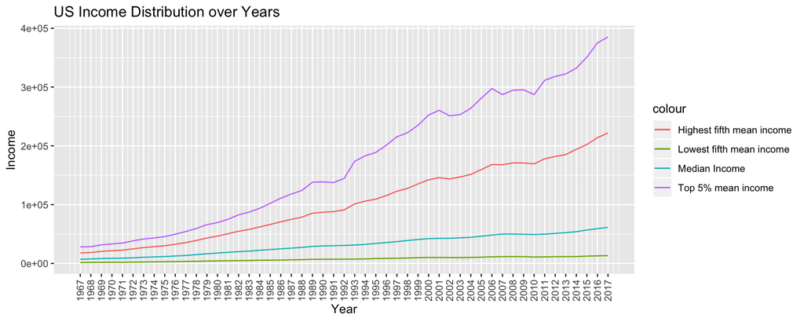

```r
#US Income distribution
ggplot(data = income_num, aes(x = Year, y=Third.fifth, colour="Median Income"))+
  geom_line()+
  geom_line(data = income_num, aes(x=Year, y=Lowest.fifth, colour="Lowest fifth mean income"))+
  geom_line(data = income_num, aes(x=Year, y=Highest.fifth, colour="Highest fifth mean income"))+
  geom_line(data = income_num, aes(x=Year, y=Top.5.percent, colour="Top 5% mean income"))+
  theme(axis.text.x = element_text(angle = 90, vjust = 0.5))+
  xlab("Year")+
  ylab("Income")+
  scale_x_continuous(breaks = income_num$Year)+
  ggtitle("US Income Distribution over Years")
```

Through the years, all income level are increasing. However, the lowest fifth mean income increases in a very slow rate while the highest fifth mean income and Top 5% mean income increase in a much faster rate. Consider the inflation, Median Income and Lowest fifth Income people might have trouble afford the health care expentiture.

#### Health Expenditures and Median Income 2000-2015

**Graph with layered data from secondary data frame**

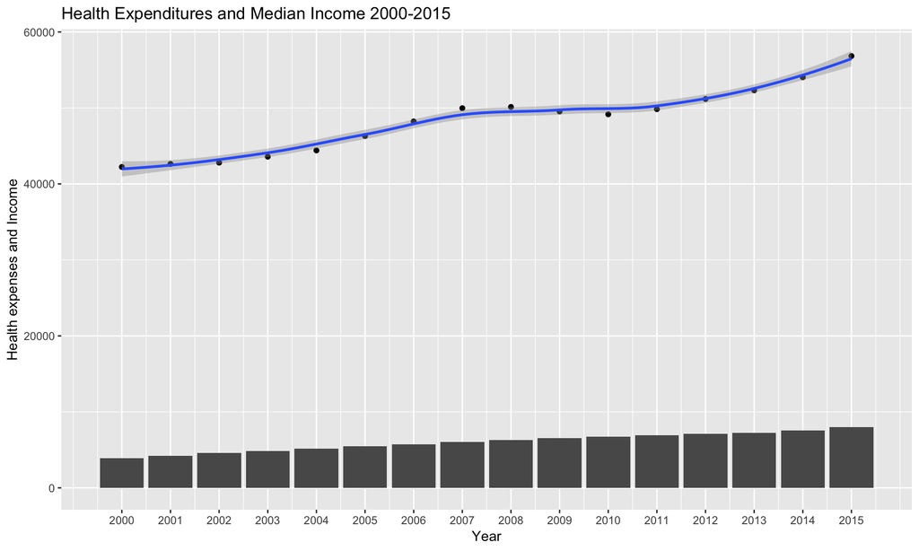

```r
#need to change the labels and titles
ggplot(data = health_percapita, aes(x = Year, y = Health)) +
  geom_bar(stat = "identity") +
  geom_point(data = income_num_sub, aes(x=Year, y=Third.fifth))+
  geom_smooth(data = income_num_sub, aes(x=Year, y=Third.fifth), show.legend = FALSE, method = "auto")+
  ggtitle("Health Expenditures and Median Income 2000-2015") +
  ylab("Health expenses and Income")+
  scale_x_continuous(breaks = insurance_income$Year)
```

#### Percent of Insurance Expenses over Income per year

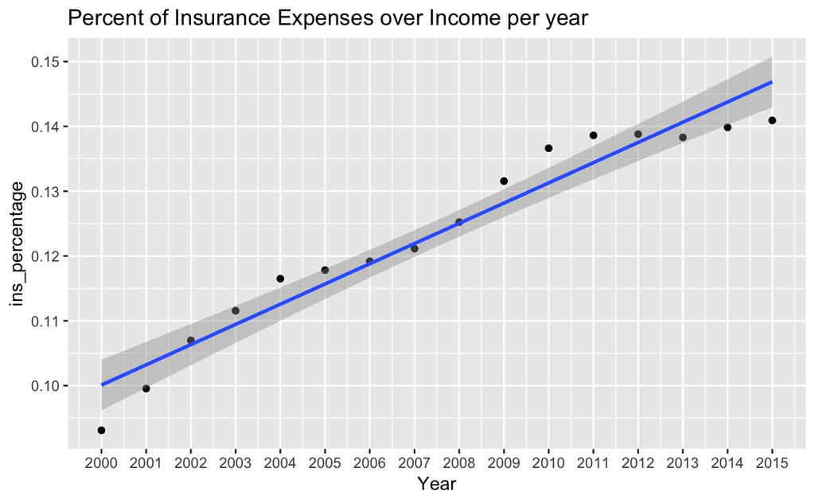

```r
ggplot(data = insurance_income, aes(x = Year, y = ins_percentage))+
  geom_point()+
  geom_smooth(method="lm")+
  ggtitle("Percent of Insurance Expenses over Income per year")+
  scale_x_continuous(breaks = insurance_income$Year)
```

The percent of health expenditure takes place over Income is increasing over the years in an approximately positive linear regression trend.

#### Income Spread based on Subject and Family Status

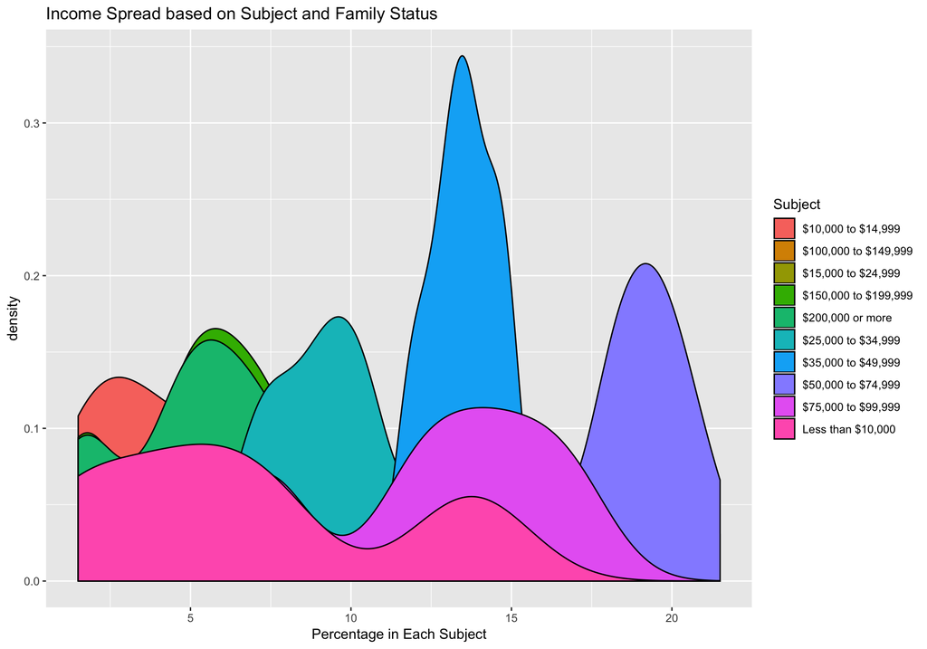

```r
ggplot(data = income, aes(x = Estimate, fill=Subject))+
  geom_density()+
  xlab("Percentage in Each Subject")+
  ggtitle("Income Spread based on Subject and Family Status")
```

# Data Analysis

## Statistical modeling/Supervised learning

#### Data Preparation

```r
# set RNG seed for reproducible results
set.seed(688)
# partition the data
n <-
  nrow(income_status)
test_idx <-
  sample.int(n, size = round(0.2 * n))
# select row numbers for the test set
train <-
  income_status[-test_idx, ]
# exclude the test set cases
nrow(train)
```

```
[1] 22
```

```r
test <-
  income_status[test_idx, ]    # test set cases only
nrow(test)
```

```
[1] 6
```

#### Inspecting training data

```r
tally(~ max, data = train)
```

```
max
$100,000 to $149,999   $15,000 to $24,999   $50,000 to $74,999
                   1                    5                   16
```

```r
tally(~ Status, data=train)
```

```
Status
               Families              Households Married-couple families
                      5                       6                       6
    NonfamilyHouseholds
                      5
```

```r
favstats(train$`$100,000 to $149,999`)
```

|  | min | Q1 | median | Q3 | max | mean | sd | n | missing |
| --- | --- | --- | --- | --- | --- | --- | --- | --- | --- |
|  | 5.1 | 12.4 | 14.1 | 17.925 | 19.9 | 13.61364 | 5.091851 | 22 | 0 |

```r
favstats(train$`$15,000 to $24,999`)
```

|  | min | Q1 | median | Q3 | max | mean | sd | n | missing |
| --- | --- | --- | --- | --- | --- | --- | --- | --- | --- |
|  | 5.2 | 6.35 | 9.5 | 10.8 | 16.7 | 10.02727 | 4.110982 | 22 | 0 |

```r
favstats(train$`$50,000 to $74,999`)
```

|  | min | Q1 | median | Q3 | max | mean | sd | n | missing |
| --- | --- | --- | --- | --- | --- | --- | --- | --- | --- |
|  | 14.8 | 17.8 | 18.75 | 20 | 21.5 | 18.37727 | 2.116136 | 22 | 0 |

```r
favstats(train$maxPerc)
```

|  | min | Q1 | median | Q3 | max | mean | sd | n | missing |
| --- | --- | --- | --- | --- | --- | --- | --- | --- | --- |
|  | 16.4 | 17.8 | 18.75 | 20 | 21.5 | 18.72273 | 1.596404 | 22 | 0 |

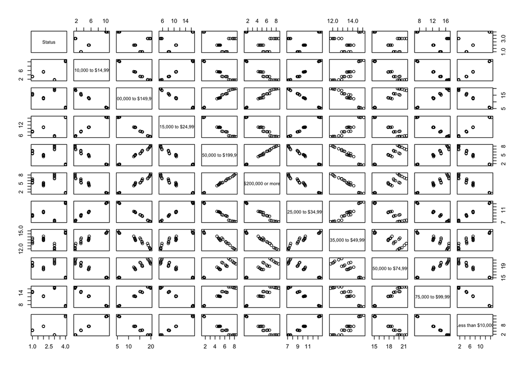

```r
pairs(train[, c(2:12)])
```

The pairs graph shows status and income are slightly correlated to each other.

### Null Model

```r
mod_null <-
  tally(~ max, data = train, format = "percent")
mod_null
```

```
max
$100,000 to $149,999   $15,000 to $24,999   $50,000 to $74,999
            4.545455            22.727273            72.727273
```

The baseline of our analysis is the percentage of people in a certain range of income. There are 4.5% of people earning $100,000 to $149,999 per year, 22.72%of people earning $15,000 to $24,999 and 72.7% of people earning $50,000 to $74,999.

```r
predictors<-
  model.matrix(maxPerc~., data = train)
fit<-
  cv.glmnet(predictors, train$maxPerc)
fit
```

```
$lambda
 [1] 1.528678808 1.392875196 1.269136002 1.156389458 1.053659006 0.960054844
 [7] 0.874766218 0.797054398 0.726246282 0.661728564 0.602942422 0.549378679
[13] 0.500573392 0.456103831 0.415584824 0.378665414 0.345025822 0.314374679
[19] 0.286446499 0.260999381 0.237812916 0.216686272 0.197436461 0.179896750
[25] 0.163915218 0.149353442 0.136085294 0.123995851 0.112980402 0.102943534
[31] 0.093798314 0.085465531 0.077873008 0.070954985 0.064651540 0.058908075
[37] 0.053674844 0.048906519 0.044561799 0.040603051 0.036995988 0.033709366
[43] 0.030714719 0.027986108 0.025499900 0.023234559 0.021170465 0.019289739
[49] 0.017576092 0.016014680 0.014591980 0.013295669 0.012114518 0.011038298
[55] 0.010057686 0.009164189 0.008350067 0.007608270 0.006932373 0.006316520
[61] 0.005755378 0.005244086 0.004778216 0.004353732 0.003966959 0.003614545
[67] 0.003293439

$cvm
```

[output cut: 155 more lines]

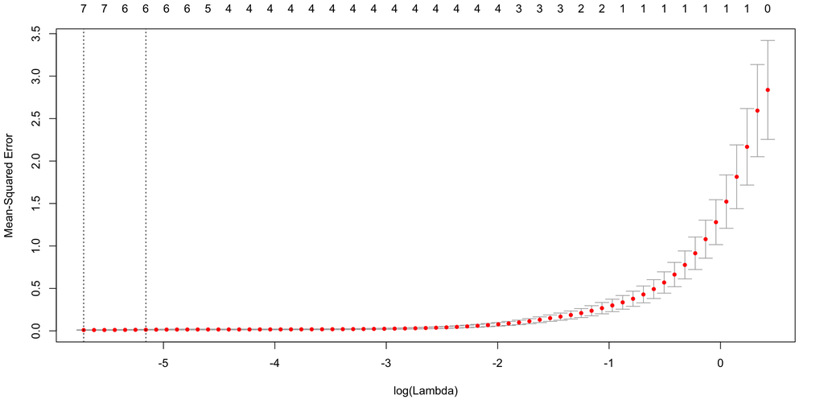

```r
plot(fit)
```

```r
mean(fit$cvlo)
```

```
[1] 0.2427093
```

```r
mean(fit$cvup)
```

```
[1] 0.378051
```

### Decision Trees

```r
rpart(max ~ `$50,000 to $74,999`, data = train)
```

```
n= 22

node), split, n, loss, yval, (yprob)
      * denotes terminal node

1) root 22 6 $50,000 to $74,999 (0.04545455 0.22727273 0.72727273)
  2) $50,000 to $74,999< 17.85 7 2 $15,000 to $24,999 (0.00000000 0.71428571 0.28571429) *
  3) $50,000 to $74,999>=17.85 15 1 $50,000 to $74,999 (0.06666667 0.00000000 0.93333333) *
```

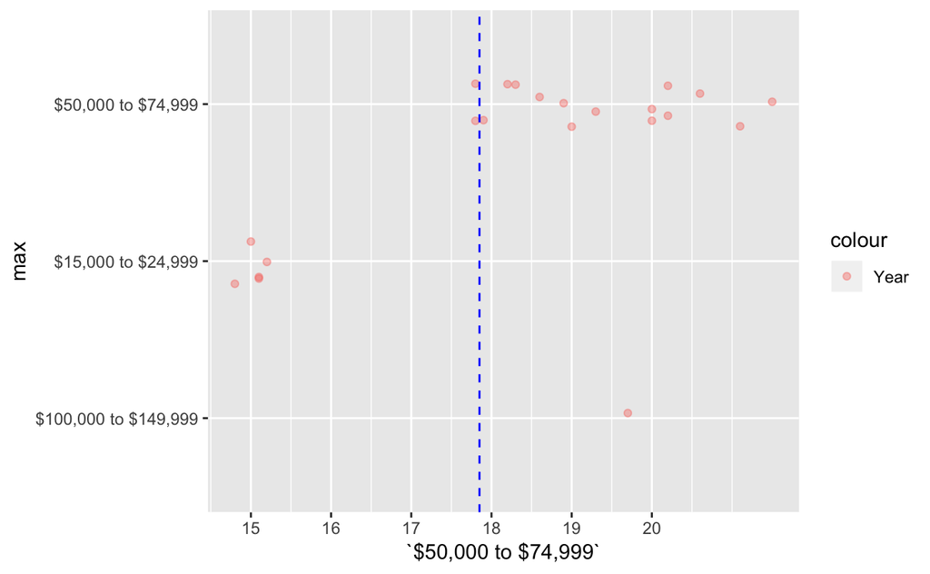

```r
split <- 17.85 # first split from simple `rpart`
train %>%
  ggplot(aes(x = `$50,000 to $74,999`, y = max)) +
  geom_point(aes(color = 'Year'),
             position = position_jitter(width = 0, height = 0.15),
             alpha = 0.4) +
  geom_vline(xintercept = split, color = "blue", lty = 2)+
  scale_x_continuous(breaks = c(1:20))
```

```r
mod_tree <-
  rpart(max~., data = train, control = rpart.control(cp=0.03))
mod_tree
```

```
n= 22

node), split, n, loss, yval, (yprob)
      * denotes terminal node

1) root 22 6 $50,000 to $74,999 (0.04545455 0.22727273 0.72727273)
  2) $100,000 to $149,999< 12.75 7 2 $15,000 to $24,999 (0.00000000 0.71428571 0.28571429) *
  3) $100,000 to $149,999>=12.75 15 1 $50,000 to $74,999 (0.06666667 0.00000000 0.93333333) *
```

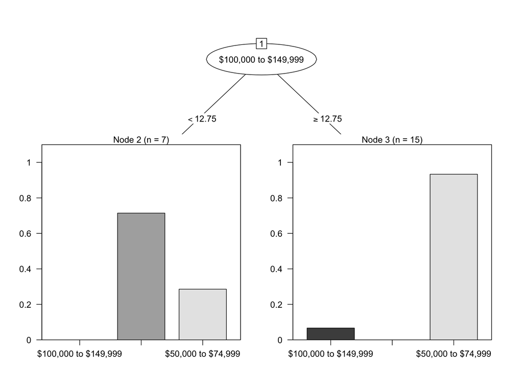

```r
plot(as.party(mod_tree))
```

```r
train_tree2 <-
  train %>%
  mutate(sub_dtree = predict(mod_tree, type = "class"))
confusion <-
  tally(sub_dtree ~ max, data = train_tree2, format = "count")
confusion
```

```
                      max
sub_dtree              $100,000 to $149,999 $15,000 to $24,999 $50,000 to $74,999
  $100,000 to $149,999                    0                  0                  0
  $15,000 to $24,999                      0                  5                  2
  $50,000 to $74,999                      1                  0                 14
```

```r
remove(train_tree2)
```

```r
sum(diag(confusion)) / nrow(train) * 100
```

```
[1] 86.36364
```

Used the rpart function set up the regression tree model for variable ‘max’ After that we split the data according to the first split in the regression tree which is at 17.85 and plot max versus income and find out data point are mostly concentrated in region ‘$50,000 to $74,999’ Then, we use the whole model of max which includes other range of income and build a complete regression tree. Finally, we plot the complete decision tree model and find the accuracy of the model.

## Unsupervised learning

### Hierarchical clustering

```r
unsuperSet<-
  insurance_income
rownames(unsuperSet)<-
  c(2000:2015)
```

```r
set_diffs<-
  dist(unsuperSet)
str(set_diffs)
```

```
 'dist' num [1:120] 8977 2905 6274 15655 34716 ...
 - attr(*, "Size")= int 16
 - attr(*, "Labels")= chr [1:16] "2000" "2001" "2002" "2003" ...
 - attr(*, "Diag")= logi FALSE
 - attr(*, "Upper")= logi FALSE
 - attr(*, "method")= chr "euclidean"
 - attr(*, "call")= language dist(x = unsuperSet)
```

```r
set_mat<-
  set_diffs %>%
  as.matrix() %>%
  round(digits = 2)
#glimpse on the matrix
set_mat[1:6, 1:6]
```

```
         2000     2001     2002     2003     2004     2005
2000     0.00  8976.66  2904.77  6274.40 15655.26 34715.80
2001  8976.66     0.00  9743.84  7752.85  7611.48 25894.94
2002  2904.77  9743.84     0.00  4448.19 15389.00 34762.54
2003  6274.40  7752.85  4448.19     0.00 11616.02 31014.53
2004 15655.26  7611.48 15389.00 11616.02     0.00 19424.44
2005 34715.80 25894.94 34762.54 31014.53 19424.44     0.00
```

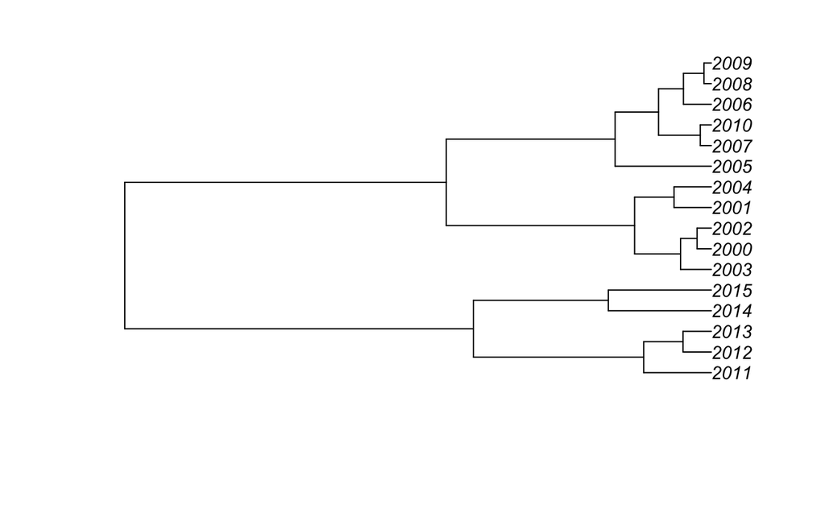

```r
set_diffs %>%
  hclust() %>%
  as.phylo() %>%
  plot(cex=0.9, label.offset = 1)
```

figure. A dendrogram constructed by hierarchical clustering from year-to-year distance data.

### K-means

We set 8 as the number of clusters and plot categoried income percentage versus year and grouped them according to the 8 clusters. Then, we change the variable to estimate versus year and plot it out again

```r
supSet<-
  insurance_income
set.seed(2500)
set_clusts_ii<-
  supSet %>%
  kmeans(centers = 8)
str(set_clusts_ii)
```

```
List of 9
 $ cluster     : int [1:16] 8 6 8 8 6 7 4 7 4 4 ...
 $ centers     : num [1:8, 1:43] 2012 2015 2014 2008 2011 ...
  ..- attr(*, "dimnames")=List of 2
  .. ..$ : chr [1:8] "1" "2" "3" "4" ...
  .. ..$ : chr [1:43] "Year" "Lowest.fifth" "Second.fifth" "Third.fifth" ...
 $ totss       : num 2.01e+10
 $ withinss    : num [1:8] 16684947 0 0 18348000 0 ...
 $ tot.withinss: num 2.05e+08
 $ betweenss   : num 1.99e+10
 $ size        : int [1:8] 2 1 1 3 1 2 3 3
 $ iter        : int 1
 $ ifault      : int 0
 - attr(*, "class")= chr "kmeans"
```

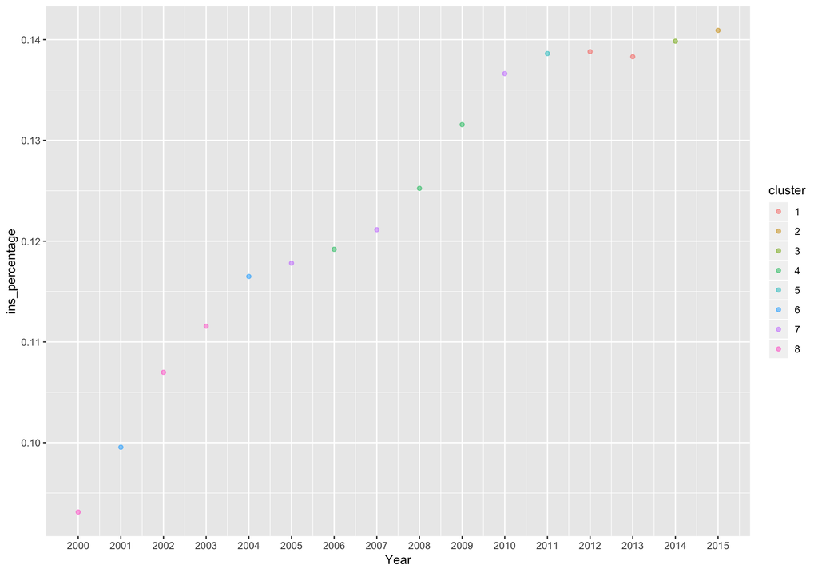

```r
set.seed(2500)
set_clusts_ii<-
  supSet %>%
  kmeans(centers = 8) %>%
  fitted("classes") %>%
  as.character()
supSet <-
  supSet %>% mutate(cluster = set_clusts_ii)
supSet %>%
  ggplot(aes(x = Year, y = ins_percentage)) +
  geom_point(aes(color = cluster), alpha = 0.5)+
  scale_x_continuous(breaks = income_num$Year)
```

```r
supSet<-
  income[,c('Year', 'Estimate')]
set.seed(1200)
set_clusts <-
  supSet %>%
  kmeans(centers = 8)
str(set_clusts)
```

```
List of 9
 $ cluster     : int [1:280] 2 2 7 7 5 1 7 7 2 2 ...
 $ centers     : num [1:8, 1:2] 2012 2010 2014 2012 2010 ...
  ..- attr(*, "dimnames")=List of 2
  .. ..$ : chr [1:8] "1" "2" "3" "4" ...
  .. ..$ : chr [1:2] "Year" "Estimate"
 $ totss       : num 9180
 $ withinss    : num [1:8] 102 127.6 139.5 142.7 82.1 ...
 $ tot.withinss: num 811
 $ betweenss   : num 8368
 $ size        : int [1:8] 24 50 51 34 36 24 25 36
 $ iter        : int 4
 $ ifault      : int 0
 - attr(*, "class")= chr "kmeans"
```

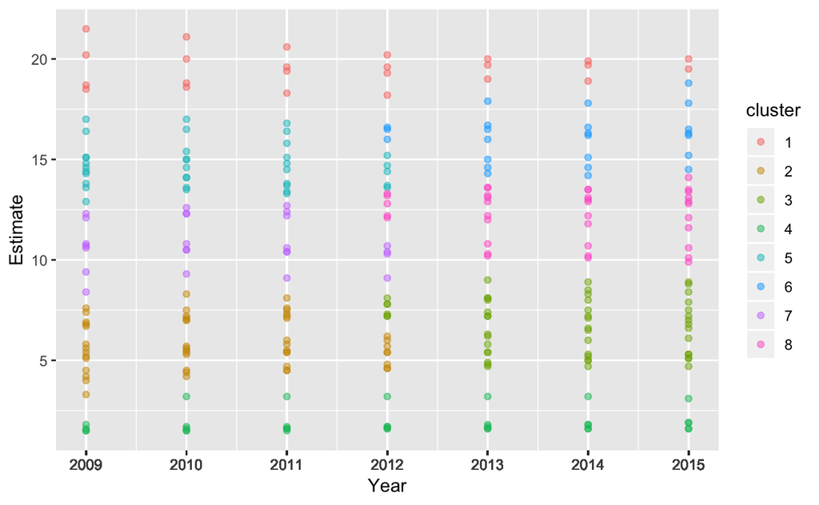

```r
set.seed(1200)
set_clusts <-
  supSet %>%
  kmeans(centers = 8) %>%
  fitted("classes") %>%
  as.character()
supSet <-
  supSet %>% mutate(cluster = set_clusts)
supSet %>%
  ggplot(aes(x = Year, y = Estimate)) +
  geom_point(aes(color = cluster), alpha = 0.5)+
  scale_x_continuous(breaks = income$Year)
```

Years that are similar tends to be grouped together, for example 2008 and 2009, 2002 and 2000. K-maens shows us the income in categories percentage per year has an increasing trend. Estimate of every year has a consistent pattern with slightly variation of the cluster, with group 4 has the lowest estimate and group 1 has the highest.

## User-defined simulation(Bootstrapping)

For the user-defined simulation. I defined a function called hein() to bootstrap data: Health.services, Medical products appliances and equipment, Third.fifth(Median Income), Highest.fifth(Income), Lowest.fifth(Income) from origin dataset, then calculate the percentage that health cost (which is the combination of the cost of Health.services+Medical productsappliances and equipment) over each level of income and organize all output into a table. Then I perform simulation 5000 times to make sure the randomness and accurancy of our simulation data.

```r
set.seed(800)
healthserv_set<-
  insurance_income$Health.services
equip_set<-
  insurance_income$Medical.products..appliances.and.equipment
income_set<-
  insurance_income$Third.fifth
income_top<-
  insurance_income$Highest.fifth
income_low<-
  insurance_income$Lowest.fifth
percent_sim<-
  do(5000)*hein(healthserv_set, equip_set, income_set, income_low, income_top)
```

```r
head(percent_sim)
```

|  | health_sim | health_service | health_equipment | medianIncome | percent_med | lowIncome | percent_low | highIncome | percent_high | .row | .index |
| --- | --- | --- | --- | --- | --- | --- | --- | --- | --- | --- | --- |
| 1 | 5002.38 | 4632.31 | 370.07 | 49842 | 0.1003648 | 10136 | 0.4935260 | 142269 | 0.03516142 | 1 | 1 |
| 2 | 5946.24 | 5743.10 | 203.14 | 52322 | 0.1136470 | 11656 | 0.5101441 | 151438 | 0.03926518 | 1 | 2 |
| 3 | 5404.39 | 5189.01 | 215.38 | 52322 | 0.1032910 | 11656 | 0.4636573 | 151438 | 0.03568715 | 1 | 3 |
| 4 | 5506.44 | 5189.01 | 317.43 | 46301 | 0.1189270 | 9990 | 0.5511952 | 185206 | 0.02973143 | 1 | 4 |
| 5 | 6870.69 | 6553.26 | 317.43 | 42233 | 0.1626853 | 10136 | 0.6778502 | 168170 | 0.04085562 | 1 | 5 |
| 6 | 7500.90 | 7164.00 | 336.90 | 52322 | 0.1433603 | 10655 | 0.7039794 | 171057 | 0.04385030 | 1 | 6 |

```r
summary(percent_sim$health_sim)
```

```
   Min. 1st Qu.  Median    Mean 3rd Qu.    Max.
   3932    5041    6176    6043    6964    8009
```

```r
summary(percent_sim$health_service)
```

```
   Min. 1st Qu.  Median    Mean 3rd Qu.    Max.
   3729    4632    5961    5739    6734    7601
```

```r
summary(percent_sim$health_equipment)
```

```
   Min. 1st Qu.  Median    Mean 3rd Qu.    Max.
  203.1   247.5   317.4   303.5   370.1   408.2
```

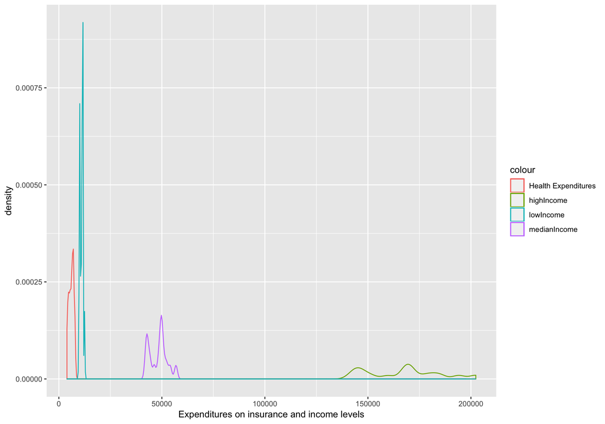

```r
ggplot(data=percent_sim, aes(x=health_sim, color="Health Expenditures"))+
  geom_density()+
  geom_density(data=percent_sim, aes(x=medianIncome, color="medianIncome"))+
  geom_density(data=percent_sim, aes(x=highIncome, color="highIncome"))+
  geom_density(data=percent_sim, aes(x=lowIncome, color="lowIncome"))+
  scale_x_continuous("Expenditures on insurance and income levels")
```

From the density graph, we can see that the lowIncome is close to the range of Health expenditures which means health expenditure is nearly unafforable for low Income people. MedianIncome has a distance from health expenditures and HighIncome is far from the health expenditure. However, in our study we do not include many situation in reality like government health converage, low income people tend to choose lower amount health care and etc. Therefore, we cannot make certain conclusions on this issue here right now.

```r
#ACA affordability percentage
#Data from https://www.integrity-data.com/a-guide-to-2019-aca-affordability-percentages-for-employers/
#data from website:
afford<-
  mean(c(0.0956, 0.0966, 0.0969, 0.0956, 0.0986))
afford
```

```
[1] 0.09666
```

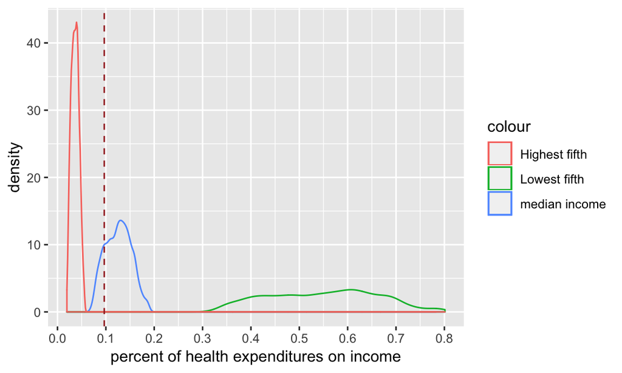

```r
ggplot(data=percent_sim, aes(x=percent_med, color="median income"))+
  geom_density()+
  geom_density(data=percent_sim, aes(x=percent_low, color="Lowest fifth"))+
  geom_density(data=percent_sim, aes(x=percent_high, color="Highest fifth"))+
  geom_vline(xintercept = afford, linetype = 2, color="Brown")+
  scale_x_continuous("percent of health expenditures on income", breaks = (0:10)/10)
```

This graph shows the percent range on health expenditures among different level of income. According to above website, the afforable level of health expenditures should around 9.6% of total income. However, many median income and low income percent have already exceed the afforable line.

## Overall Conclusion:

Upon college students take their first job, they are often surprised by the health care costs that take up a huge part of their paycheck. As insurance is not a neglectable aspect of our spending, in this project we discussed the percent of insurance of net income, and further analyze what is the reasonable range of insurance that everyone can afford. After all the analysis, we found out that insurance is becoming unaffordable to many people, especially for low-income family. However,we did not take policy and overall economy status into account, for example, ACA and some companies will provide insurance to their employees. Conclusion: Making the insurance pool larger will make it more affordable. However, more people have to pay for insurance too so we should find an optimum point.